# 23202425_Machine_learning_foundations_project

**IS41070 Machine Learning Foundations Project**

**Install Necessary Packages**

In this section, we will install the necessary packages for our project. These include:

- `pandas` for data manipulation and analysis
- `numpy` for numerical operations
- `seaborn` for statistical data visualization
- `nltk` for natural language processing
- `matplotlib` for plotting and visualization
- `wordcloud` for generating word clouds from text data
- `scikit-learn` for machine learning algorithms and tools

```python
# Install pandas for data manipulation and analysis
!pip install pandas
```

```python
# Install numpy for numerical operations
!pip install numpy
```

```python
# Install seaborn for statistical data visualization
!pip install seaborn
```

```python
# Install nltk for natural language processing
!pip install nltk
```

```python
# Install matplotlib for plotting and visualization
!pip install matplotlib
```

```python
# Install wordcloud for generating word clouds from text data
!pip install wordcloud
```

```python
# Install scikit-learn for machine learning algorithms and tools
!pip install scikit-learn
```

**Data Understanding & Exploration**

Loading the Dataset, we will load the dataset provided for the project. This dataset contains news articles and their corresponding categories. We will use `pandas` to load the data and perform initial exploration.

```python
import pandas as pd  # Import the pandas library for data manipulation

news_data= pd.read_csv('22.csv')# Load the dataset from the CSV file into a DataFrame

news_data.head() # Display the first few rows of the DataFrame to check the data
```

|  | Unnamed: 0 | category | headline | authors | link | short_description | date |
| --- | --- | --- | --- | --- | --- | --- | --- |
| 0 | 0 | POLITICS | Democrats, Republicans Take Advantage Of New B... | Paul Blumenthal | https://www.huffingtonpost.com/entry/mccutcheo... | NaN | 2014-10-17 |
| 1 | 1 | CRIME | WATCH: Truck Plows Into Stolen Car, Ends Reckl... | Isaac Saul | https://www.huffingtonpost.com/entry/truck-plo... | NaN | 2014-06-02 |
| 2 | 2 | POLITICS | On Patriotism | Robert Reich, ContributorChancellor's Professo... | https://www.huffingtonpost.com/entry/on-patrio... | True patriotism isn't simply about waving the ... | 2015-07-04 |
| 3 | 3 | CRIME | Former WWF Wrestler Severely Beaten Outside Ca... | David Lohr | https://www.huffingtonpost.com/entry/former-ww... | "He's really lucky to be alive," a neighbor said. | 2018-05-18 |
| 4 | 4 | POLITICS | The End of the Commonwealth | John Tirman, ContributorExecutive Director, MI... | https://www.huffingtonpost.com/entry/the-end-o... | The worldview of Trump and those he’s bringing... | 2016-12-13 |

Data Exploration

we will perform an initial exploration of the dataset. This includes:

- Checking the basic structure of the dataset
- Exploring the distribution of categories
- Analyzing the text data (most common terms, sentence lengths, etc.)
- Checking for missing values and outliers

Basic description of Data

```python
news_data.info() # Display information about the DataFrame, such as the number of rows and columns, data types, and non-null counts
```

```
<class 'pandas.core.frame.DataFrame'>
RangeIndex: 8000 entries, 0 to 7999
Data columns (total 7 columns):
 #   Column             Non-Null Count  Dtype
---  ------             --------------  -----
 0   Unnamed: 0         8000 non-null   int64
 1   category           7980 non-null   object
 2   headline           7984 non-null   object
 3   authors            6787 non-null   object
 4   link               7986 non-null   object
 5   short_description  7002 non-null   object
 6   date               7977 non-null   object
dtypes: int64(1), object(6)
memory usage: 437.6+ KB
```

Lets remane the First column to "S.no"

```python
news_data.rename(columns={'Unnamed: 0': 'S.no'}, inplace=True) # Rename the column 'Unnamed: 0' to 'S.no'
```

```python
news_data.head() # Display the first few rows of the DataFrame to verify the change
```

|  | S.no | category | headline | authors | link | short_description | date |
| --- | --- | --- | --- | --- | --- | --- | --- |
| 0 | 0 | POLITICS | Democrats, Republicans Take Advantage Of New B... | Paul Blumenthal | https://www.huffingtonpost.com/entry/mccutcheo... | NaN | 2014-10-17 |
| 1 | 1 | CRIME | WATCH: Truck Plows Into Stolen Car, Ends Reckl... | Isaac Saul | https://www.huffingtonpost.com/entry/truck-plo... | NaN | 2014-06-02 |
| 2 | 2 | POLITICS | On Patriotism | Robert Reich, ContributorChancellor's Professo... | https://www.huffingtonpost.com/entry/on-patrio... | True patriotism isn't simply about waving the ... | 2015-07-04 |
| 3 | 3 | CRIME | Former WWF Wrestler Severely Beaten Outside Ca... | David Lohr | https://www.huffingtonpost.com/entry/former-ww... | "He's really lucky to be alive," a neighbor said. | 2018-05-18 |
| 4 | 4 | POLITICS | The End of the Commonwealth | John Tirman, ContributorExecutive Director, MI... | https://www.huffingtonpost.com/entry/the-end-o... | The worldview of Trump and those he’s bringing... | 2016-12-13 |

Distribution of Categories

```
category
POLITICS    5984
CRIME       1996
Name: count, dtype: int64
```

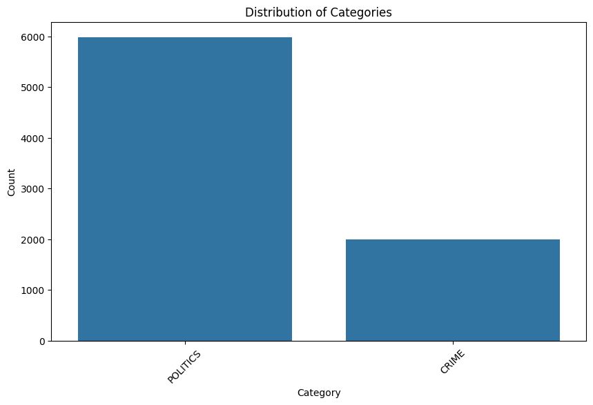

```python
category_distribution = news_data['category'].value_counts() # Display the distribution of categories
print(category_distribution)


import matplotlib.pyplot as plt # Plot the distribution of categories
import seaborn as sns

plt.figure(figsize=(10, 6))
sns.countplot(data=news_data, x='category', order=category_distribution.index)
plt.title('Distribution of Categories')
plt.xlabel('Category')
plt.ylabel('Count')
plt.xticks(rotation=45)
plt.show()
```

The dataset has a significant imbalance, with 5984 instances of "POLITICS" compared to 1996 instances of "CRIME." This disparity can cause the model to become biased towards predicting "POLITICS" more frequently. As a result, the model's predictions may be skewed, favoring "POLITICS" and leading to inaccurate results. Additionally, the model's sensitivity to the "CRIME" category will be reduced, with lower recall and precision, causing many true "CRIME" instances to be missed or misclassified.

```python
news_data.describe(include='all') # Display summary statistics of the DataFrame, including count, unique values, top values, and frequency for categorical data
```

|  | S.no | category | headline | authors | link | short_description | date |
| --- | --- | --- | --- | --- | --- | --- | --- |
| count | 8000.00000 | 7980 | 7984 | 6787 | 7986 | 7002 | 7977 |
| unique | NaN | 2 | 7964 | 1795 | 7984 | 6948 | 1632 |
| top | NaN | POLITICS | Sunday Roundup | Sam Levine | https://www.huffingtonpost.comhttp://www.nytim... | Welcome to the HuffPost Rise Morning Newsbrief... | 2014-11-05 |
| freq | NaN | 5984 | 20 | 148 | 2 | 41 | 18 |
| mean | 3999.50000 | NaN | NaN | NaN | NaN | NaN | NaN |
| std | 2309.54541 | NaN | NaN | NaN | NaN | NaN | NaN |
| min | 0.00000 | NaN | NaN | NaN | NaN | NaN | NaN |
| 25% | 1999.75000 | NaN | NaN | NaN | NaN | NaN | NaN |
| 50% | 3999.50000 | NaN | NaN | NaN | NaN | NaN | NaN |
| 75% | 5999.25000 | NaN | NaN | NaN | NaN | NaN | NaN |
| max | 7999.00000 | NaN | NaN | NaN | NaN | NaN | NaN |

checking for missing values

Its always important to check the data for completeness( for higher accuracy of the model)

```python
missing_values = news_data.isnull().sum() # Check for missing values
missing_values  # Display the count of missing values for each column
```

```
S.no                    0
category               20
headline               16
authors              1213
link                   14
short_description     998
date                   23
dtype: int64
```

We can see that several columns have missing values, but our primary concern is the category column. This column plays a crucial role in training the model it determines the classification of each article into specific categories, such as POLITICS or CRIME based on content.

We will remove those 20 rows where we have no categories

```python
news_data_cleaned = news_data.dropna(subset=['category']) # Drop rows where 'category' is NaN

# Check the result
missing_values_after = news_data_cleaned.isnull().sum()
missing_values_after
```

```
S.no                    0
category                0
headline               16
authors              1211
link                   14
short_description     998
date                   23
dtype: int64
```

```python
news_data_cleaned.describe(include='all') # Display summary statistics of the DataFrame, including count, unique values, top values, and frequency for categorical data
```

|  | S.no | category | headline | authors | link | short_description | date |
| --- | --- | --- | --- | --- | --- | --- | --- |
| count | 7980.000000 | 7980 | 7964 | 6769 | 7966 | 6982 | 7957 |
| unique | NaN | 2 | 7944 | 1792 | 7964 | 6928 | 1630 |
| top | NaN | POLITICS | Sunday Roundup | Sam Levine | https://www.huffingtonpost.comhttp://www.nytim... | Welcome to the HuffPost Rise Morning Newsbrief... | 2014-11-05 |
| freq | NaN | 5984 | 20 | 148 | 2 | 41 | 18 |
| mean | 3998.022431 | NaN | NaN | NaN | NaN | NaN | NaN |
| std | 2308.868917 | NaN | NaN | NaN | NaN | NaN | NaN |
| min | 0.000000 | NaN | NaN | NaN | NaN | NaN | NaN |
| 25% | 1998.750000 | NaN | NaN | NaN | NaN | NaN | NaN |
| 50% | 3997.500000 | NaN | NaN | NaN | NaN | NaN | NaN |
| 75% | 5997.250000 | NaN | NaN | NaN | NaN | NaN | NaN |
| max | 7999.000000 | NaN | NaN | NaN | NaN | NaN | NaN |

**Data Analysis**

```python
import nltk
from nltk.corpus import stopwords
from nltk.tokenize import word_tokenize
from nltk.stem import WordNetLemmatizer


nltk.download('punkt') # Download necessary NLTK data
nltk.download('stopwords')
nltk.download('wordnet')
```

```
True
```

```python
news_data_copy = news_data_cleaned.copy() # Create a copy of the DataFrame to avoid modifying the original data
```

```python
news_data_copy['headline'] = news_data_copy['headline'].fillna('')

news_data_copy['short_description'] = news_data_copy['short_description'].fillna('')  # Fill missing values in the 'short_description' column with empty strings
```

```python
# Verify that there are no more missing values
missing_values_after = news_data_copy.isnull().sum()
print(missing_values_after)  # Display the count of missing values for each column to confirm
```

```
S.no                    0
category                0
headline                0
authors              1211
link                   14
short_description       0
date                   23
dtype: int64
```

```python
lemmatizer = WordNetLemmatizer() # Initialize the WordNetLemmatizer
stop_words = set(stopwords.words('english'))


def preprocess_text(text):  # Define a function to preprocess text (tokenize, remove stopwords, and lemmatize)
    tokens = word_tokenize(text.lower())  # Tokenize and convert to lowercase
    filtered_tokens = [lemmatizer.lemmatize(word) for word in tokens if word.isalpha() and word not in stop_words]  # Remove stopwords and lemmatize
    return ' '.join(filtered_tokens)
```

```python
news_data_copy['text'] = news_data_copy['headline'] + ' ' + news_data_copy['short_description'] # Combine the 'headline' and 'short_description' into a single text column for vectorization


news_data_copy['processed_text'] = news_data_copy['text'].apply(preprocess_text) # Apply the preprocessing function to the 'text' column


news_data_copy[['text', 'processed_text']].head() # Display the first few rows of the DataFrame to verify the preprocessing
```

|  | text | processed_text |
| --- | --- | --- |
| 0 | Democrats, Republicans Take Advantage Of New B... | democrat republican take advantage new rule |
| 1 | WATCH: Truck Plows Into Stolen Car, Ends Reckl... | watch truck plow stolen car end reckless joyride |
| 2 | On Patriotism True patriotism isn't simply abo... | patriotism true patriotism simply waving ameri... |
| 3 | Former WWF Wrestler Severely Beaten Outside Ca... | former wwf wrestler severely beaten outside ca... |
| 4 | The End of the Commonwealth The worldview of T... | end commonwealth worldview trump bringing gove... |

```python
# Import necessary libraries
from collections import Counter  # To count word frequencies
import matplotlib.pyplot as plt  # For plotting
import seaborn as sns  # For more advanced plotting
```

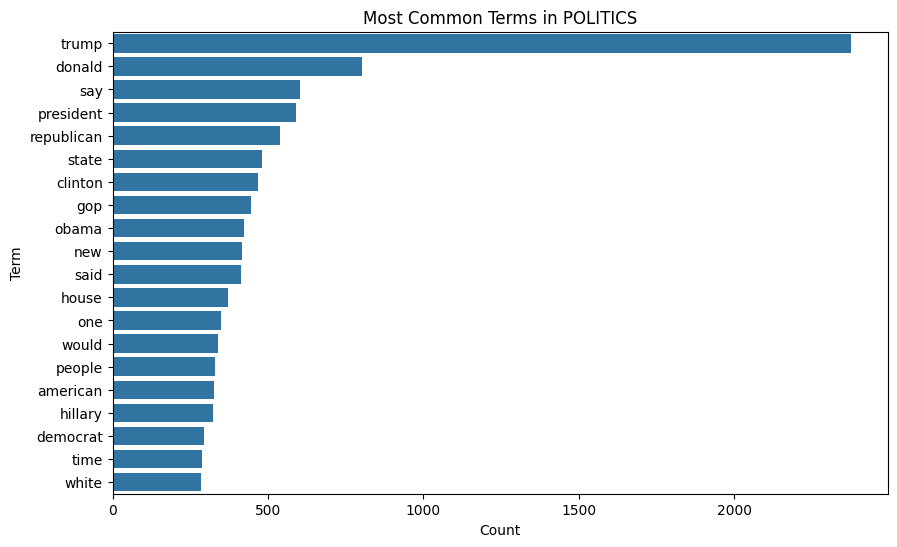

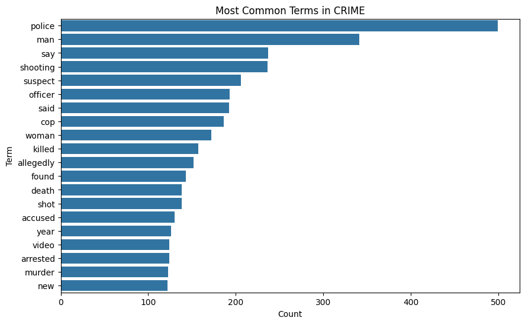

```python
def plot_most_common_terms(data, category, num_terms=20): #Plot the most common terms in a specific category.

    category_data = data[data['category'] == category] # Filter data for the specific category

    all_text = ' '.join(category_data['processed_text'])  # Combine all processed text into a single string

    word_counts = Counter(all_text.split())  # Tokenize the combined text and count the terms

    common_terms = word_counts.most_common(num_terms)    # Get the most common terms

    common_terms_df = pd.DataFrame(common_terms, columns=['term', 'count']) # Create a DataFrame for plotting

    plt.figure(figsize=(10, 6))   # Plot the most common terms using seaborn's barplot
    sns.barplot(x='count', y='term', data=common_terms_df)
    plt.title(f'Most Common Terms in {category}')
    plt.xlabel('Count')
    plt.ylabel('Term')
    plt.show()

for category in news_data_copy['category'].unique(): # Plot the most common terms for each category
    plot_most_common_terms(news_data_copy, category)
```

Key Observations: Politics:

- "Trump" is the most frequent term by a large margin.
- Political Figures: Frequent mentions of "donald," "clinton," "obama," and "hillary."
- Political Terms: Common words include "president," "republican," "state," and "gop."

Crime:

- "Police" is the most common term.
- High frequency of "man," "shooting," "suspect," "officer," and "killed."
- Common terms include "death," "found," "shot," "accused," and "arrested."

we can further analyze other features in the dataset and their relationship with the category

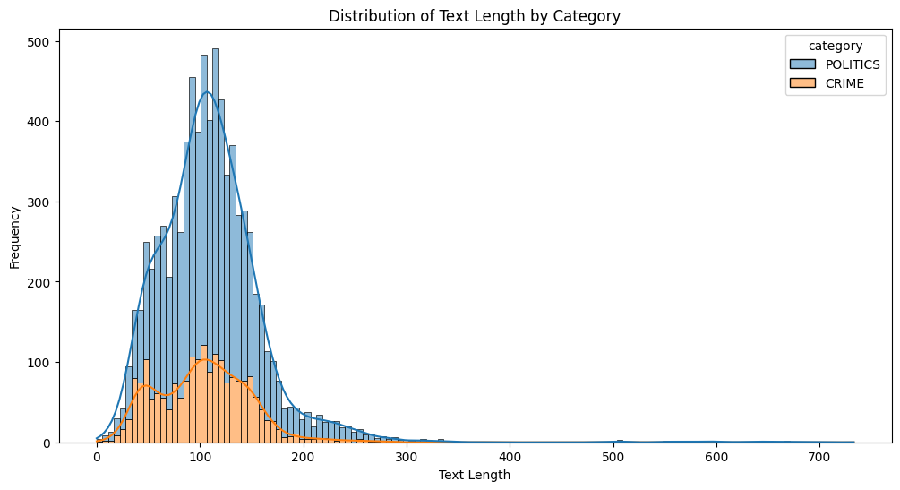

```python
news_data_copy['text_length'] = news_data_copy['processed_text'].apply(len) # Add a column for the length of the processed text

plt.figure(figsize=(12, 6)) # Plot the distribution of text length for each category
sns.histplot(data=news_data_copy, x='text_length', hue='category', multiple='stack', kde=True)
plt.title('Distribution of Text Length by Category')
plt.xlabel('Text Length')
plt.ylabel('Frequency')
plt.show()
```

Observations:

- "POLITICS" category shows an approximately normal distribution with a peak around 100 characters.
- "CRIME" category has a similar distribution but with lower frequency.
- High concentration of articles in both categories within the 50 to 150 character range.
- "POLITICS" articles exhibit a wider spread, some exceeding 500 characters.
- "CRIME" articles show less variation, with fewer long articles.
- "POLITICS" articles are more frequent overall compared to "CRIME" articles.
- Some outliers in the "POLITICS" category have text lengths greater than 400 characters.
- Political articles are generally longer and more frequent than crime-related articles.

```python
news_data_copy.head()
```

|  | S.no | category | headline | authors | link | short_description | date | text | processed_text | text_length |
| --- | --- | --- | --- | --- | --- | --- | --- | --- | --- | --- |
| 0 | 0 | POLITICS | Democrats, Republicans Take Advantage Of New B... | Paul Blumenthal | https://www.huffingtonpost.com/entry/mccutcheo... |  | 2014-10-17 | Democrats, Republicans Take Advantage Of New B... | democrat republican take advantage new rule | 43 |
| 1 | 1 | CRIME | WATCH: Truck Plows Into Stolen Car, Ends Reckl... | Isaac Saul | https://www.huffingtonpost.com/entry/truck-plo... |  | 2014-06-02 | WATCH: Truck Plows Into Stolen Car, Ends Reckl... | watch truck plow stolen car end reckless joyride | 48 |
| 2 | 2 | POLITICS | On Patriotism | Robert Reich, ContributorChancellor's Professo... | https://www.huffingtonpost.com/entry/on-patrio... | True patriotism isn't simply about waving the ... | 2015-07-04 | On Patriotism True patriotism isn't simply abo... | patriotism true patriotism simply waving ameri... | 114 |
| 3 | 3 | CRIME | Former WWF Wrestler Severely Beaten Outside Ca... | David Lohr | https://www.huffingtonpost.com/entry/former-ww... | "He's really lucky to be alive," a neighbor said. | 2018-05-18 | Former WWF Wrestler Severely Beaten Outside Ca... | former wwf wrestler severely beaten outside ca... | 92 |
| 4 | 4 | POLITICS | The End of the Commonwealth | John Tirman, ContributorExecutive Director, MI... | https://www.huffingtonpost.com/entry/the-end-o... | The worldview of Trump and those he’s bringing... | 2016-12-13 | The End of the Commonwealth The worldview of T... | end commonwealth worldview trump bringing gove... | 91 |

```python
news_data_copy = news_data_copy[(news_data_copy['text_length'] <= 450) & (news_data_copy['text_length'] >= 50)] # Remove outliers based on text length

# Verify the cleaning process
news_data_copy.info()
```

```
<class 'pandas.core.frame.DataFrame'>
Index: 7225 entries, 2 to 7999
Data columns (total 10 columns):
 #   Column             Non-Null Count  Dtype
---  ------             --------------  -----
 0   S.no               7225 non-null   int64
 1   category           7225 non-null   object
 2   headline           7225 non-null   object
 3   authors            6214 non-null   object
 4   link               7212 non-null   object
 5   short_description  7225 non-null   object
 6   date               7203 non-null   object
 7   text               7225 non-null   object
 8   processed_text     7225 non-null   object
 9   text_length        7225 non-null   int64
dtypes: int64(2), object(8)
memory usage: 620.9+ KB
```

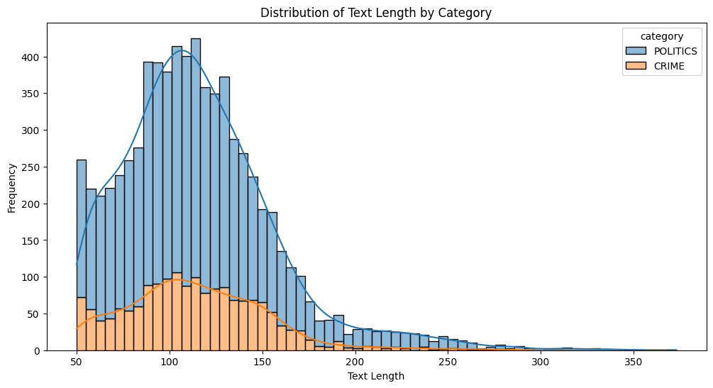

```python
news_data_copy['text_length'] = news_data_copy['processed_text'].apply(len) # Add a column for the length of the processed text

plt.figure(figsize=(12, 6)) # Plot the distribution of text length for each category
sns.histplot(data=news_data_copy, x='text_length', hue='category', multiple='stack', kde=True)
plt.title('Distribution of Text Length by Category')
plt.xlabel('Text Length')
plt.ylabel('Frequency')
plt.show()
```

We have removed the outliers and ensured that the total text length (Headline + Short Description) is between 50 and 450 characters.

**Data Preparation**

Since we have noticed a significant imbalance in your dataset, it's crucial to split your data in a way that maintains the distribution of the classes across training, validation, and test sets. An effective approach would be using stratified sampling, which ensures that each subset has approximately the same class distribution as the original dataset.

```python
from sklearn.model_selection import train_test_split  # Import train_test_split for splitting the dataset

# First, split the data into training (80%) and testing sets (20%)
train_df, test_df = train_test_split(news_data_copy, test_size=0.2, random_state=42, stratify=news_data_copy['category'])

# Then, split the training set further into training (60% of original data) and validation sets (20% of original data)
train_df, valid_df = train_test_split(train_df, test_size=0.25, random_state=42, stratify=train_df['category'])

# Save the training, validation, and testing sets to CSV files
train_df.to_csv('train.csv', index=False)
valid_df.to_csv('valid.csv', index=False)
test_df.to_csv('test.csv', index=False)
```

Verify and check the distribution of the splits

```python
# Verify the splits
print("Training set size:", train_df.shape[0])
print("Validation set size:", valid_df.shape[0])
print("Testing set size:", test_df.shape[0])

# Check the distribution of categories in each set
print("\nTraining set category distribution:\n", train_df['category'].value_counts())
print("\nValidation set category distribution:\n", valid_df['category'].value_counts())
print("\nTesting set category distribution:\n", test_df['category'].value_counts())
```

```
Training set size: 4335
Validation set size: 1445
Testing set size: 1445

Training set category distribution:
 category
POLITICS    3317
CRIME       1018
Name: count, dtype: int64

Validation set category distribution:
 category
POLITICS    1105
CRIME        340
Name: count, dtype: int64

Testing set category distribution:
 category
POLITICS    1106
CRIME        339
Name: count, dtype: int64
```

```python
# Display the first few rows of the training data to check the loaded data
train_df.head()
```

|  | S.no | category | headline | authors | link | short_description | date | text | processed_text | text_length |
| --- | --- | --- | --- | --- | --- | --- | --- | --- | --- | --- |
| 7384 | 7384 | POLITICS | This Is How Much Time Students Actually Spend ... | JENNIFER C. KERR AND JOSH LEDERMAN, AP | https://www.huffingtonpost.com/entry/standardi... | Testing amounts to about 2.3 percent of classr... | 2015-10-26 | This Is How Much Time Students Actually Spend ... | much time student actually spend taking standa... | 117 |
| 1089 | 1089 | POLITICS | Gun Advocate Wants Bars To Serve Less Booze So... | Liz Adetiba | https://www.huffingtonpost.com/entry/larry-pra... | Obviously. | 2016-06-20 | Gun Advocate Wants Bars To Serve Less Booze So... | gun advocate want bar serve le booze everyone ... | 65 |
| 4548 | 4548 | POLITICS | Mitt Romney Tweets He's Not Donald Trump's Sec... | Peter Andrew Hart | https://www.huffingtonpost.com/entry/mitt-romn... | Trump is expected to name Exxon Mobil's Rex Ti... | 2016-12-13 | Mitt Romney Tweets He's Not Donald Trump's Sec... | mitt romney tweet donald trump secretary state... | 113 |
| 7551 | 7551 | POLITICS | Being Donald Trump Means Never Having To Say Y... | Dave Jamieson | https://www.huffingtonpost.com/entry/being-don... | Here's a riddle: If you don't say what you're ... | 2016-08-20 | Being Donald Trump Means Never Having To Say Y... | donald trump mean never say sorry riddle say a... | 73 |
| 5887 | 5887 | CRIME | Man Allegedly Threatens To Cut Throat Of Off-D... | Ron Dicker | https://www.huffingtonpost.com/entry/off-duty-... | "Go back to your country," suspect told Aml El... | 2016-12-05 | Man Allegedly Threatens To Cut Throat Of Off-D... | man allegedly threatens cut throat muslim nypd... | 112 |

```python
# Display the first few rows of the validation data to check the loaded data
valid_df.head()
```

|  | S.no | category | headline | authors | link | short_description | date | text | processed_text | text_length |
| --- | --- | --- | --- | --- | --- | --- | --- | --- | --- | --- |
| 2345 | 2345 | POLITICS | I Don’t Support Trump, But I’m Attending His I... | Jon Savitt, ContributorWriter. Comedian \| jons... | https://www.huffingtonpost.com/entry/i-dont-su... | When it comes to the 58th Presidential Inaugur... | 2017-01-15 | I Don’t Support Trump, But I’m Attending His I... | support trump attending inauguration come pres... | 122 |
| 930 | 930 | POLITICS | Looks Like The 'Burger King's' Subjects Are Ro... | Richard (RJ) Eskow, ContributorHost, The Zero ... | https://www.huffingtonpost.com/entry/looks-lik... | An informal boycott seems to have started alre... | 2014-08-29 | Looks Like The 'Burger King's' Subjects Are Ro... | look like king subject royally pissed informal... | 169 |
| 3449 | 3449 | CRIME | Dayton Air Show: Wing Walker Plane Crash Repor... | NaN | https://www.huffingtonpost.com/entry/dayton-ai... | More from the Associated Press: The show was c... | 2013-06-22 | Dayton Air Show: Wing Walker Plane Crash Repor... | dayton air show wing walker plane crash report... | 126 |
| 7699 | 7699 | CRIME | Florida Man Plotted ISIS-Inspired Backpack Bom... | Andres Jauregui | https://www.huffingtonpost.com/entry/florida-m... | He also considered detonating bombs at Fourth ... | 2015-07-29 | Florida Man Plotted ISIS-Inspired Backpack Bom... | florida man plotted backpack bombing beach fed... | 102 |
| 6507 | 6507 | POLITICS | Trump Voter Fraud Commissioner Says Panel Shou... | Sam Levine | https://www.huffingtonpost.com/entry/trump-vot... | Democratic commissioner Alan King was unsparin... | 2017-10-24 | Trump Voter Fraud Commissioner Says Panel Shou... | trump voter fraud commissioner say panel trans... | 114 |

Vectorizing the Text Data

We will use the TF-IDF vectorizer to convert the text data into numerical features.

```python
from sklearn.feature_extraction.text import TfidfVectorizer  # Import TfidfVectorizer for converting text to numeric features

# Combine preprocessing and TF-IDF vectorization in a single step
vectorizer = TfidfVectorizer(
    lowercase=True,  # Convert all characters to lowercase
    stop_words='english',  # Remove English stopwords
    max_features=5000  # Consider only the top 5000 words by frequency
)

X_train = vectorizer.fit_transform(train_df['processed_text']) # Fit the vectorizer on the training data and transform the text data into TF-IDF features
X_valid = vectorizer.transform(valid_df['processed_text'])

print("Shape of X_train:", X_train.shape) # Display the shape of the resulting feature matrices
print("Shape of X_valid:", X_valid.shape)

y_train = train_df['category'] # Extract the labels (categories) from the training and validation data
y_valid = valid_df['category']
```

```
Shape of X_train: (4335, 5000)
Shape of X_valid: (1445, 5000)
```

**Building and Evaluating Machine Learning Models**

we will use Logistic Regression and Support Vector Machine (SVM).

- Logistic Regression was chosen because of its simplicity, speed, and probabilistic results.
- SVM was chosen for its efficacy in high-dimensional text data and resistance to overfitting.

  These models work together to achieve balanced performance and interpretability.

Logistic Regression

We will start with a simple Logistic Regression model to set a baseline performance.

```python
from sklearn.linear_model import LogisticRegression
from sklearn.metrics import classification_report, accuracy_score, confusion_matrix

# Initialize the model
log_reg = LogisticRegression(max_iter=1000, random_state=42)

# Train the model
log_reg.fit(X_train, y_train)

# Make predictions on the validation set
y_pred_log_reg = log_reg.predict(X_valid)

# Evaluate the model on the validation set
print("Logistic Regression Performance on Validation Set:")
print(f"Accuracy: {accuracy_score(y_valid, y_pred_log_reg)}")
print(classification_report(y_valid, y_pred_log_reg))

# Generate confusion matrix
cm = confusion_matrix(y_valid, y_pred_log_reg)
print("Confusion Matrix:\n", cm)
```

```
Logistic Regression Performance on Validation Set:
Accuracy: 0.9065743944636678
              precision    recall  f1-score   support

       CRIME       0.94      0.65      0.77       340
    POLITICS       0.90      0.99      0.94      1105

    accuracy                           0.91      1445
   macro avg       0.92      0.82      0.85      1445
weighted avg       0.91      0.91      0.90      1445

Confusion Matrix:
 [[ 220  120]
 [  15 1090]]
```

Support Vector Machine (SVM)

we will build a Support Vector Machine classifier to further test our models.

```python
from sklearn.svm import SVC

# Initialize the model
svm_clf = SVC(kernel='linear', random_state=42)

# Train the model
svm_clf.fit(X_train, y_train)

# Make predictions on the validation set
y_pred_svm = svm_clf.predict(X_valid)

# Evaluate the model on the validation set
print("Support Vector Machine Performance on Validation Set:")
print(f"Accuracy: {accuracy_score(y_valid, y_pred_svm)}")
print(classification_report(y_valid, y_pred_svm))

# Generate confusion matrix
cm = confusion_matrix(y_valid, y_pred_svm)
print("Confusion Matrix:\n", cm)
```

```
Support Vector Machine Performance on Validation Set:
Accuracy: 0.928719723183391
              precision    recall  f1-score   support

       CRIME       0.90      0.79      0.84       340
    POLITICS       0.94      0.97      0.95      1105

    accuracy                           0.93      1445
   macro avg       0.92      0.88      0.90      1445
weighted avg       0.93      0.93      0.93      1445

Confusion Matrix:
 [[ 267   73]
 [  30 1075]]
```

**Building Our Own Deep Learning Model**

We will use TensorFlow/Keras to create a simple LSTM model(type of recurrent neural network (RNN)).

we are using the Long Short-term memory(LSTM) model as they can learn, process, and classify sequential data because these networks can learn long-term dependencies between time steps of data.

```python
!pip install tensorflow
```

```python
import tensorflow as tf
from tensorflow.keras.preprocessing.text import Tokenizer
from tensorflow.keras.preprocessing.sequence import pad_sequences
from tensorflow.keras.models import Sequential
from tensorflow.keras.layers import Embedding, LSTM, Dense, Dropout

# Combine text columns and preprocess the data
train_texts = train_df['processed_text']
valid_texts = valid_df['processed_text']

# Tokenize and pad sequences
tokenizer = Tokenizer(num_words=10000, oov_token='<OOV>')
tokenizer.fit_on_texts(train_texts)
train_sequences = tokenizer.texts_to_sequences(train_texts)
valid_sequences = tokenizer.texts_to_sequences(valid_texts)
train_padded = pad_sequences(train_sequences, maxlen=500, padding='post', truncating='post')
valid_padded = pad_sequences(valid_sequences, maxlen=500, padding='post', truncating='post')

# Encode labels
from sklearn.preprocessing import LabelEncoder
le = LabelEncoder()
y_train = le.fit_transform(train_df['category'])
y_valid = le.transform(valid_df['category'])
```

Build LSTM model

```python
model = Sequential([
    Embedding(10000, 64, input_length=450),
    LSTM(64, return_sequences=True),
    Dropout(0.2),
    LSTM(64),
    Dropout(0.2),
    Dense(1, activation='sigmoid')
])

model.compile(loss='binary_crossentropy', optimizer='adam', metrics=['accuracy'])

# Train the model
history = model.fit(train_padded, y_train, epochs=10, validation_data=(valid_padded, y_valid), batch_size=64)
```

```
68/68 ━━━━━━━━━━━━━━━━━━━━ 18s 229ms/step - accuracy: 0.7397 - loss: 0.5791 - val_accuracy: 0.7647 - val_loss: 0.5459
68/68 ━━━━━━━━━━━━━━━━━━━━ 16s 232ms/step - accuracy: 0.7673 - loss: 0.5450 - val_accuracy: 0.7647 - val_loss: 0.5584
68/68 ━━━━━━━━━━━━━━━━━━━━ 16s 233ms/step - accuracy: 0.7618 - loss: 0.5545 - val_accuracy: 0.7647 - val_loss: 0.5468
68/68 ━━━━━━━━━━━━━━━━━━━━ 16s 234ms/step - accuracy: 0.7575 - loss: 0.5551 - val_accuracy: 0.7647 - val_loss: 0.5461
68/68 ━━━━━━━━━━━━━━━━━━━━ 16s 235ms/step - accuracy: 0.7666 - loss: 0.5477 - val_accuracy: 0.7647 - val_loss: 0.5462
68/68 ━━━━━━━━━━━━━━━━━━━━ 16s 232ms/step - accuracy: 0.7617 - loss: 0.5532 - val_accuracy: 0.7647 - val_loss: 0.5477
68/68 ━━━━━━━━━━━━━━━━━━━━ 16s 230ms/step - accuracy: 0.7766 - loss: 0.5363 - val_accuracy: 0.7647 - val_loss: 0.5467
68/68 ━━━━━━━━━━━━━━━━━━━━ 16s 232ms/step - accuracy: 0.7726 - loss: 0.5389 - val_accuracy: 0.7647 - val_loss: 0.5460
68/68 ━━━━━━━━━━━━━━━━━━━━ 16s 229ms/step - accuracy: 0.7662 - loss: 0.5478 - val_accuracy: 0.7647 - val_loss: 0.5460
68/68 ━━━━━━━━━━━━━━━━━━━━ 16s 231ms/step - accuracy: 0.7692 - loss: 0.5427 - val_accuracy: 0.7647 - val_loss: 0.5466
```

Evaluate the Model

```python
loss, accuracy = model.evaluate(valid_padded, y_valid)
print(f'Validation Accuracy: {accuracy}')
print(f'Validation Loss: {loss}')
```

```
46/46 ━━━━━━━━━━━━━━━━━━━━ 2s 45ms/step - accuracy: 0.7711 - loss: 0.5383
Validation Accuracy: 0.7647058963775635
Validation Loss: 0.5465911626815796
```

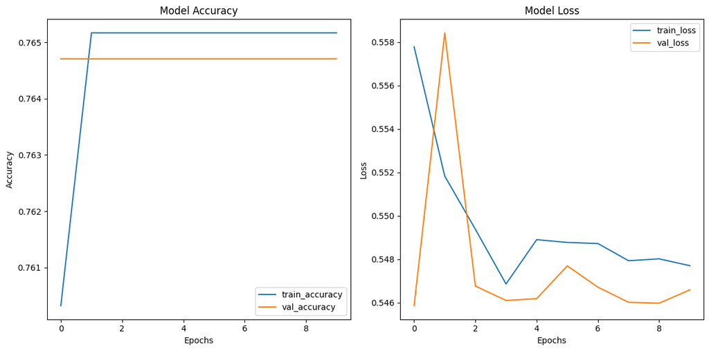

```python
# Plot training & validation accuracy and loss
plt.figure(figsize=(12, 6))

# Plot accuracy
plt.subplot(1, 2, 1)
plt.plot(history.history['accuracy'], label='train_accuracy')
plt.plot(history.history['val_accuracy'], label='val_accuracy')
plt.title('Model Accuracy')
plt.xlabel('Epochs')
plt.ylabel('Accuracy')
plt.legend(loc='lower right')

# Plot loss
plt.subplot(1, 2, 2)
plt.plot(history.history['loss'], label='train_loss')
plt.plot(history.history['val_loss'], label='val_loss')
plt.title('Model Loss')
plt.xlabel('Epochs')
plt.ylabel('Loss')
plt.legend(loc='upper right')

plt.tight_layout()
plt.show()
```

**EVALUATION**

**Error Analysis**

Own Deep Learning MOdel:

```python
# Predict the validation data
y_pred = (model.predict(valid_padded) > 0.5).astype("int32")

# Generate a classification report
from sklearn.metrics import classification_report, confusion_matrix

print("Classification Report:\n", classification_report(y_valid, y_pred))
print("Confusion Matrix:\n", confusion_matrix(y_valid, y_pred))
```

```
46/46 ━━━━━━━━━━━━━━━━━━━━ 2s 47ms/step
Classification Report:
               precision    recall  f1-score   support

           0       0.00      0.00      0.00       340
           1       0.76      1.00      0.87      1105

    accuracy                           0.76      1445
   macro avg       0.38      0.50      0.43      1445
weighted avg       0.58      0.76      0.66      1445

Confusion Matrix:
 [[   0  340]
 [   0 1105]]
```

```python
# Determine the mapping based on known class distribution
politics_class = 1  # Larger class (5528 instances)
crime_class = 0     # Smaller class (1697 instances)

print(f"Class {crime_class} corresponds to CRIME.")
print(f"Class {politics_class} corresponds to POLITICS.")
```

```
Class 0 corresponds to CRIME.
Class 1 corresponds to POLITICS.
```

Based on the above classification Report

Class 0: CRIME

- Precision: 0.00 - The model never correctly predicted class 0.
- Recall: 0.00 - Out of all the actual class 0 instances, the model didn't get any right.
- F1-Score: 0.00 - Overall performance for class 0 is very poor.

Class 1: POLITICS

- Precision: 0.76 - 76% of the time the model predicted class 1 correctly.
- Recall: 1.00 - The model identified all actual class 1 instances correctly.
- F1-Score: 0.87 - Good performance for class 1.

Overall Accuracy: 0.76 - 76% of the total predictions are correct, but this is mostly because the model is good at predicting class 1( due to significant imbalance, with 5984 instances of "POLITICS" compared to 1996 instances of "CRIME." )

The model is biased towards the majority class (class 1: POLITICS).

Logistic Regression & SVM :

```python
from sklearn.linear_model import LogisticRegression
from sklearn.metrics import classification_report, accuracy_score, confusion_matrix
from sklearn.svm import SVC

# Initialize the model
log_reg = LogisticRegression(max_iter=1000, random_state=42)

# Train the model
log_reg.fit(X_train, y_train)

# Make predictions on the validation set
y_pred_log_reg = log_reg.predict(X_valid)

# Evaluate the model on the validation set
print("Logistic Regression Performance on Validation Set:")
print(f"Accuracy: {accuracy_score(y_valid, y_pred_log_reg)}")
print(classification_report(y_valid, y_pred_log_reg))

# Generate confusion matrix
cm = confusion_matrix(y_valid, y_pred_log_reg)
print("Confusion Matrix:\n", cm)

# Initialize the model
svm_clf = SVC(kernel='linear', random_state=42)

# Train the model
svm_clf.fit(X_train, y_train)

# Make predictions on the validation set
y_pred_svm = svm_clf.predict(X_valid)

# Evaluate the model on the validation set
print("Support Vector Machine Performance on Validation Set:")
print(f"Accuracy: {accuracy_score(y_valid, y_pred_svm)}")
print(classification_report(y_valid, y_pred_svm))

# Generate confusion matrix
cm = confusion_matrix(y_valid, y_pred_svm)
print("Confusion Matrix:\n", cm)
```

```
Logistic Regression Performance on Validation Set:
Accuracy: 0.9065743944636678
              precision    recall  f1-score   support

           0       0.94      0.65      0.77       340
           1       0.90      0.99      0.94      1105

    accuracy                           0.91      1445
   macro avg       0.92      0.82      0.85      1445
weighted avg       0.91      0.91      0.90      1445

Confusion Matrix:
 [[ 220  120]
 [  15 1090]]
Support Vector Machine Performance on Validation Set:
Accuracy: 0.928719723183391
              precision    recall  f1-score   support

           0       0.90      0.79      0.84       340
           1       0.94      0.97      0.95      1105

    accuracy                           0.93      1445
   macro avg       0.92      0.88      0.90      1445
weighted avg       0.93      0.93      0.93      1445

Confusion Matrix:
 [[ 267   73]
 [  30 1075]]
```

From above, It is clearly evident that SVM model have the higher accuarcy over other two models.

Logistic Regression:

- High accuracy (~91%) and good performance overall.
- Struggles more with identifying CRIME (lower recall of 0.65), indicating many CRIME articles are misclassified as POLITICS.
- POLITICS classification is strong (high recall and precision).
- Out of 340 CRIME instances, 220 were correctly classified, and 120 were misclassified as POLITICS.
- Out of 1105 POLITICS instances, 1090 were correctly classified, and 15 were misclassified as CRIME.

Support Vector Machine:

- Higher accuracy (~93%) than Logistic Regression.
- Better balance in classifying both CRIME and POLITICS.
- Improved recall for CRIME (0.79) compared to Logistic Regression, indicating fewer CRIME articles are misclassified.

We will use the F1-score as our major assessment metric. A single measure that balances false positives and false negatives is the F1-score, which is the harmonic mean of precision and recall. This is especially important with imbalanced datasets, when accuracy may not provide a clear view of model performance.

Given the imbalance in our dataset (more instances of "POLITICS" than "CRIME"), the F1-score ensures that our model performs well across both classes rather than just the majority class.

**MODEL IMPROVEMENT**

Logistic Regression Model:

```python
from sklearn.linear_model import LogisticRegression
from sklearn.metrics import classification_report, accuracy_score, confusion_matrix
from sklearn.preprocessing import StandardScaler
from sklearn.model_selection import GridSearchCV

# Feature Scaling
scaler = StandardScaler(with_mean=False)
X_train_scaled = scaler.fit_transform(X_train)
X_valid_scaled = scaler.transform(X_valid)

# Initialize the model with GridSearchCV for hyperparameter tuning
param_grid = {'C': [0.01, 0.1, 1, 10, 100]}
grid_search = GridSearchCV(LogisticRegression(max_iter=1000, random_state=42), param_grid, cv=5, scoring='accuracy')
grid_search.fit(X_train_scaled, y_train)

# Best estimator after hyperparameter tuning
log_reg_best = grid_search.best_estimator_

# Make predictions on the validation set
y_pred_log_reg_best = log_reg_best.predict(X_valid_scaled)

# Evaluate the model on the validation set
print("Improved Logistic Regression Performance on Validation Set:")
print(f"Accuracy: {accuracy_score(y_valid, y_pred_log_reg_best)}")
print(classification_report(y_valid, y_pred_log_reg_best))

# Generate confusion matrix
cm_best = confusion_matrix(y_valid, y_pred_log_reg_best)
print("Confusion Matrix:\n", cm_best)
```

```
Improved Logistic Regression Performance on Validation Set:
Accuracy: 0.9114186851211072
              precision    recall  f1-score   support

           0       0.85      0.76      0.80       340
           1       0.93      0.96      0.94      1105

    accuracy                           0.91      1445
   macro avg       0.89      0.86      0.87      1445
weighted avg       0.91      0.91      0.91      1445

Confusion Matrix:
 [[ 258   82]
 [  46 1059]]
```

Key Improvements:

- Feature Scaling: We standardized the data, ensuring that all features are on the same scale. This allows the Logistic Regression model to learn more successfully since it treats each feature equally.
- Hyperparameter Tuning: We utilized GridSearchCV for testing with alternative values for a model parameter (C). This technique assisted us in determining the ideal configuration for the model, hence boosting its performance.

Support Vector Machine Model(Use Ensemble Approach):

```python
from sklearn.ensemble import VotingClassifier
from sklearn.linear_model import LogisticRegression
from sklearn.naive_bayes import MultinomialNB

# Initialize base models
lr = LogisticRegression()
nb = MultinomialNB()
svm = SVC(kernel='rbf', probability=True)

# Create an ensemble model
ensemble_clf = VotingClassifier(estimators=[
    ('lr', lr), ('nb', nb), ('svm', svm)], voting='soft')

# Train the ensemble model
ensemble_clf.fit(X_train_scaled, y_train)

# Make predictions on the validation set
y_pred_ensemble = ensemble_clf.predict(X_valid_scaled)

# Evaluate the model
print("Ensemble Model Performance on Validation Set:")
print(f"Accuracy: {accuracy_score(y_valid, y_pred_ensemble)}")
print(classification_report(y_valid, y_pred_ensemble))

# Generate confusion matrix
cm_ensemble = confusion_matrix(y_valid, y_pred_ensemble)
print("Confusion Matrix:\n", cm_ensemble)
```

```
Ensemble Model Performance on Validation Set:
Accuracy: 0.9141868512110727
              precision    recall  f1-score   support

           0       0.83      0.80      0.81       340
           1       0.94      0.95      0.94      1105

    accuracy                           0.91      1445
   macro avg       0.88      0.87      0.88      1445
weighted avg       0.91      0.91      0.91      1445

Confusion Matrix:
 [[ 271   69]
 [  55 1050]]
```

Despite a slight decline in overall performance compared to the Support Vector Machine (SVM) model, the current ensemble model demonstrates several positive aspects.

Positive Aspects of the Current Ensemble Model:

might perform well, when trained with large data.

- Now, we are left with an Improved Logistic Regression Model and Ensemble Model

**CROSS VALIDATION**

Merge both training and validation sets to perform cross validation

```python
# Merge the training and validation sets
crossvalid = pd.concat([train_df, valid_df], axis=0).reset_index(drop=True)

# Extract features and labels
X_crossvalid = crossvalid['processed_text']
y_crossvalid = crossvalid['category']

# Print the number of rows in the combined dataset
print(f"Number of rows in X_crossvalid: {X_crossvalid.shape[0]}")
```

```
Number of rows in X_crossvalid: 5780
```

vectorizing the cross validation dataset

```python
# Initialize the vectorizer
vectorizer = TfidfVectorizer(
    lowercase=True,  # Convert all characters to lowercase
    stop_words='english',  # Remove English stopwords
    max_features=5000  # Consider only the top 5000 words by frequency
)

# Fit the vectorizer on the combined data and transform the text data into TF-IDF features
X_crossvalid_vectorized = vectorizer.fit_transform(X_crossvalid)
```

cross-validation using improved Logistic regression Model

```python
# Feature Scaling
scaler = StandardScaler(with_mean=False)
X_crossvalid_scaled = scaler.fit_transform(X_crossvalid_vectorized)

# Initialize the model with GridSearchCV for hyperparameter tuning
param_grid = {'C': [0.01, 0.1, 1, 10, 100]}
grid_search = GridSearchCV(LogisticRegression(max_iter=1000, random_state=42), param_grid, cv=5, scoring='accuracy')
grid_search.fit(X_crossvalid_scaled, y_crossvalid)

# Best estimator after hyperparameter tuning
log_reg_best = grid_search.best_estimator_

# Make predictions on the cross- validation set

y_pred_log_reg_best = log_reg_best.predict(X_crossvalid_scaled)

# Evaluate the model on the validation set
print("Improved Logistic Regression Performance on Validation Set:")
print(f"Accuracy: {accuracy_score(y_crossvalid, y_pred_log_reg_best)}")
print(classification_report(y_crossvalid, y_pred_log_reg_best))

# Generate confusion matrix
cm_best = confusion_matrix(y_crossvalid, y_pred_log_reg_best)
print("Confusion Matrix:\n", cm_best)
```

```
Improved Logistic Regression Performance on Validation Set:
Accuracy: 1.0
              precision    recall  f1-score   support

       CRIME       1.00      1.00      1.00      1358
    POLITICS       1.00      1.00      1.00      4422

    accuracy                           1.00      5780
   macro avg       1.00      1.00      1.00      5780
weighted avg       1.00      1.00      1.00      5780

Confusion Matrix:
 [[1358    0]
 [   0 4422]]
```

The observed faultless performance during cross-validation suggests that the model is most likely being tested on the same data that it was trained on. This leads to overfitting, in which the model memorizes the training data and achieves 100% accuracy on the validation set. This is not a realistic assessment of the model's performance on actually unseen data.

Cross-validation using Ensemble Model

```python
from sklearn.metrics import accuracy_score, classification_report, confusion_matrix
from sklearn.preprocessing import LabelEncoder

# Fit LabelEncoder on training data and transform both train and validation data
label_encoder = LabelEncoder()
y_true_numeric = label_encoder.fit_transform(crossvalid['category'])
y_pred_ensemble_crossvalid = ensemble_clf.predict(X_crossvalid_vectorized)

# Evaluate the model on the cross-validation set
print("Ensemble Model Performance on Cross-Validation Set:")
print(f"Accuracy: {accuracy_score(y_true_numeric, y_pred_ensemble_crossvalid)}")
print(classification_report(y_true_numeric, y_pred_ensemble_crossvalid))
cm_ensemble_crossvalid = confusion_matrix(y_true_numeric, y_pred_ensemble_crossvalid)
print("Confusion Matrix on Cross-Validation Set:\n", cm_ensemble_crossvalid)
```

```
Ensemble Model Performance on Cross-Validation Set:
Accuracy: 0.7650519031141868
              precision    recall  f1-score   support

           0       0.00      0.00      0.00      1358
           1       0.77      1.00      0.87      4422

    accuracy                           0.77      5780
   macro avg       0.38      0.50      0.43      5780
weighted avg       0.59      0.77      0.66      5780

Confusion Matrix on Cross-Validation Set:
 [[   0 1358]
 [   0 4422]]
```

So far, Our best model is improved Logistic regression Model

Appying it to Test dataset

```python
# Load the test set
test_df = pd.read_csv('test.csv')
X_test = test_df['processed_text']
y_test = test_df['category']

# Initialize the vectorizer
vectorizer = TfidfVectorizer(
    lowercase=True,  # Convert all characters to lowercase
    stop_words='english',  # Remove English stopwords
    max_features=5000  # Consider only the top 5000 words by frequency
)


# Initialize the scaler
scaler = StandardScaler(with_mean=False)
# Transform the test data using the fitted vectorizer and scaler
X_test_vectorized = vectorizer.fit_transform(X_test)
X_test_scaled = scaler.fit_transform(X_test_vectorized)

# Make predictions on the test set
y_pred_log_reg_best_test = log_reg_best.predict(X_test_scaled)

# Evaluate the model on the test set
print("Improved Logistic Regression Performance on Test Set:")
print(f"Accuracy: {accuracy_score(y_test, y_pred_log_reg_best_test)}")
print(classification_report(y_test, y_pred_log_reg_best_test))

# Generate confusion matrix
cm_best_test = confusion_matrix(y_test, y_pred_log_reg_best_test)
print("Confusion Matrix on Test Set:\n", cm_best_test)
```

```
Improved Logistic Regression Performance on Test Set:
Accuracy: 0.7169550173010381
              precision    recall  f1-score   support

       CRIME       0.23      0.09      0.13       339
    POLITICS       0.77      0.91      0.83      1106

    accuracy                           0.72      1445
   macro avg       0.50      0.50      0.48      1445
weighted avg       0.64      0.72      0.67      1445

Confusion Matrix on Test Set:
 [[  30  309]
 [ 100 1006]]
```

This Model when validated with the same data a trained performed flawlessly, but as we evaluated on the unseen independent test set., its performance went down. we will retrain this model with a combined dataset of training and validation data and check for any improvements.

retraining our improving logistic regression Model with combined train and valid datasets

Applying this re_trained Model to test data set

```python
# Load the training and validation sets
train_df = pd.read_csv('train.csv')
valid_df = pd.read_csv('valid.csv')

# Combine the training and validation sets for vectorizer fitting
full_train_df = pd.concat([train_df, valid_df])
X_full_train = full_train_df['processed_text']
y_full_train = full_train_df['category']

# Initialize the vectorizer
vectorizer = TfidfVectorizer(
    lowercase=True,  # Convert all characters to lowercase
    stop_words='english',  # Remove English stopwords
    max_features=5000  # Consider only the top 5000 words by frequency
)

# Fit the vectorizer on the combined training data and transform the training data
X_full_train_vectorized = vectorizer.fit_transform(X_full_train)

# Initialize the scaler
scaler = StandardScaler(with_mean=False)

# Fit the scaler on the combined training data and transform the training data
X_full_train_scaled = scaler.fit_transform(X_full_train_vectorized)

# Initialize the model with GridSearchCV for hyperparameter tuning
param_grid = {'C': [0.01, 0.1, 1, 10, 100]}
grid_search = GridSearchCV(LogisticRegression(max_iter=1000, random_state=42), param_grid, cv=5, scoring='accuracy')
grid_search.fit(X_full_train_scaled, y_full_train)

# Best estimator after hyperparameter tuning
log_reg_best = grid_search.best_estimator_

# Train the best model on the full training data
log_reg_best.fit(X_full_train_scaled, y_full_train)

# Load the test set
test_df = pd.read_csv('test.csv')
X_test = test_df['processed_text']
y_test = test_df['category']

# Transform the test data using the fitted vectorizer and scaler
X_test_vectorized = vectorizer.transform(X_test)
X_test_scaled = scaler.transform(X_test_vectorized)

# Make predictions on the test set
y_pred_log_reg_best_test = log_reg_best.predict(X_test_scaled)

# Evaluate the model on the test set
print("Improved Logistic Regression Performance on Test Set:")
print(f"Accuracy: {accuracy_score(y_test, y_pred_log_reg_best_test)}")
print(classification_report(y_test, y_pred_log_reg_best_test))

# Generate confusion matrix
cm_best_test = confusion_matrix(y_test, y_pred_log_reg_best_test)
print("Confusion Matrix on Test Set:\n", cm_best_test)
```

```
Improved Logistic Regression Performance on Test Set:
Accuracy: 0.9211072664359862
              precision    recall  f1-score   support

       CRIME       0.89      0.76      0.82       339
    POLITICS       0.93      0.97      0.95      1106

    accuracy                           0.92      1445
   macro avg       0.91      0.86      0.88      1445
weighted avg       0.92      0.92      0.92      1445

Confusion Matrix on Test Set:
 [[ 256   83]
 [  31 1075]]
```

The retraining of the logistic regression model resulted in significant improvements in both accuracy and F1-score. The model's accuracy increased from 71.7% to 92.1%, indicating a substantial enhancement in overall prediction correctness. Moreover, the F1-score improved notably for both classes, particularly for class 0, rising from 13% to 82%. This indicates that the model now performs well not only in correctly classifying instances overall but also in achieving a balanced precision-recall trade-off for both the majority and minority classes.

```python
# Save the trained model to a file
import joblib
joblib.dump(log_reg_best, 'logreg_improved_model.pkl')
```

```
['logreg_improved_model.pkl']
```

```python
loaded_model = joblib.load('logreg_improved_model.pkl') # Verify that the model can be loaded and produce the same results
y_pred = log_reg_best.predict(X_test_scaled)
loaded_test_accuracy = accuracy_score(y_test, y_pred)
print("Loaded Model Test Set Accuracy:", loaded_test_accuracy)
```

```
Loaded Model Test Set Accuracy: 0.9211072664359862
```